# The Capability Gap

- Show All Code
- Hide All Code
- View Source

Each focal country’s recent standing against the common target profile — how far, and in which direction. The country layer of the target-profile work.

Author

Net Zero Industrial Policy Lab (NZIPL) · Johns Hopkins SAIS

Published

July 7, 2026

```r
library(readr); library(dplyr); library(tidyr); library(stringr); library(forcats)
library(ggplot2); library(patchwork); library(knitr); library(showtext); library(tibble)
font_add_google("Archivo", "Archivo"); showtext_auto(); showtext_opts(dpi = 200)

NZ_DARK <- "#073309"; NZ_GREEN <- "#3cb54a"; NZ_TEAL <- "#0d9488"
theme_nr <- function(...) theme_minimal(base_family = "Archivo", base_size = 12) +
  theme(plot.title = element_text(size = 14, face = "bold", colour = NZ_DARK),
        plot.subtitle = element_text(size = 11, colour = "#475569"),
        panel.grid.minor = element_blank(), ...)
theme_set(theme_nr())
CAT_COL <- c(Chemicals="#2563eb", Electronics="#7c3aed", Metals="#ef4444",
             Machinery="#10b981", "Industrial Materials"="#f59e0b")
CATS <- c("Chemicals","Electronics","Industrial Materials","Machinery","Metals")
CATS_SHORT <- c(Chemicals="Chem", Electronics="Elec", "Industrial Materials"="Ind.M",
                Machinery="Mach", Metals="Met")
TECHS <- c("Solar","Wind","Batteries","EVs","Nuclear","Geothermal",
           "Heat Pumps","Electrolyzers","Transmission","Magnets","Biofuel")
FOCAL <- c("Brazil","India","Mexico","Japan","Vietnam","Spain")
# tech colour palette (matches the Atlas) — used to paint each tech's own "need" profile
TECH_COLORS <- c(Solar="#eab308", Nuclear="#0ea5e9", Batteries="#f59e0b", Transmission="#06b6d4",
                 Wind="#3b82f6", Biofuel="#84cc16", Electrolyzers="#a855f7", Geothermal="#ef4444",
                 "Heat Pumps"="#f97316", Magnets="#ec4899", EVs="#14b8a6")
CGREEN <- "#22c55e"   # one shiny green for "what the country actually holds"

# tidytext::reorder_within shim (avoid the dependency)
reorder_within <- function(x, by, within, sep="___") stats::reorder(paste(x, within, sep=sep), by)

gap <- read_csv(here::here("analysis","ml","shap_gap_by_country_cluster.csv"), show_col_types = FALSE) |>
  mutate(tech = factor(tech, TECHS), country = factor(country, FOCAL),
         cluster = factor(cluster, CATS),
         # % of target reached, capped. coalesce: when a tech has NO retained features in a
         # cluster its target weight is 0, so achieved is 0/0=NaN — treat that axis as 0 so the
         # pentagon closes cleanly instead of breaking into a sliver.
         ach = pmin(pmax(coalesce(achieved, 0), 0), 1))
front <- gap |> group_by(country, tech) |>
  summarise(frontier = sum(pmax(country_signed, 0)) / sum(target_weight), .groups = "drop")
```

**Where this sits.** `target_profile.qmd` established the **target** layer — a defensible common per-tech capability profile (the winners’ recipe). This is the **gap** layer: for each of the six focal countries, its *own* recent signed SHAP (option A: mean over the last 3 available years) read against that target, per capability cluster. The target is a shared *shape*, but countries differ enormously in *level and direction* — which is exactly what the gap surfaces. Built by `scripts/ml/target_profile_prep.py` from `analysis/ml/raw_signed/`; no model re-fit.

# 1 How to read the gap

The whole point of this note is to make one question concrete: *if this country wanted to become competitive in this technology, what would it build?* The target-profile note gave us the destination — a common per-tech “need” profile, the winners’ recipe across the five capability clusters. Here we lay each country’s *own* recent capability (its mean signed SHAP over the last three years, per cluster) against that destination. Everything below is two numbers per country × technology × cluster — **what the technology needs** and **what the country currently has** — shown two complementary ways.

**The building block: an achievement fraction.** For each cluster we form

$$\text{achieved} \;=\; \frac{\text{country's recent signed SHAP in the cluster}}{\text{target (winners') weight in the cluster}}$$

read as *the share of the frontier the country has reached there*. A value of **1.0 means “at the frontier”** (the country already has the competitive producers’ level of that capability); **below 1.0 is a gap** — how far there is to build; **above 1.0 is a surplus** — capability beyond what the target needs, a candidate to leverage or redeploy.

**Two radar views, because they answer different questions.** We draw the same data both ways on purpose:

- The **relative** radar normalises every cluster by its own target, so the outer pentagon is *always* the frontier (100%) and the green fill is the fraction reached. This view puts every technology on the same 0–100% footing, which is what you want when *ranking* where a country is close versus distant, and when reading build priorities off the short axes. Its cost: it hides how big the underlying need is — a near-full pentagon on a tiny-need technology and on a huge-need one look alike.
- The **absolute** radar keeps the raw magnitudes. It overlays two shapes on a shared per-panel scale: the technology’s **need profile, drawn in that technology’s own colour**, and **what the country actually holds, in green**. This view restores the sense of scale the relative view drops — you see the *shape* of the need and how much of it the country fills — and it reads especially well for technologies where the country is far behind (a large coloured need with only a sliver of green inside).

Together they make the argument the audit set up: because the target is a shared *shape* (countries rank-agree at ρ≈0.89), what distinguishes countries is **level and direction** — how full the radar is, and which axes are short — precisely the magnitude and country-specific signal the shipped count-driven radar threw away.

# 2 Distance to the frontier — the whole board

Before the cluster-by-cluster detail, it helps to see the whole map at once. Collapsing all five clusters into a single number per country × technology — the total share of the target the country has reached — gives an executive summary: which technologies are within a country’s reach, and which are distant. This is the “where to look” view; the radars that follow are the “why.”

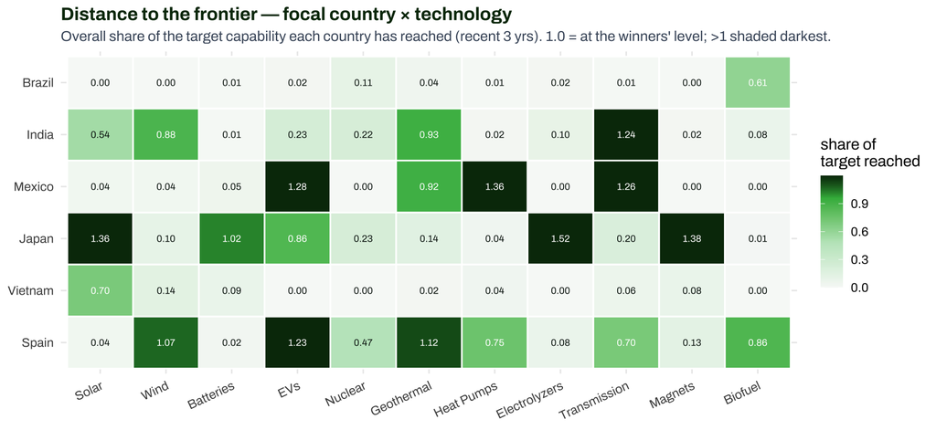

```r
hd <- front |> mutate(country = factor(country, rev(FOCAL)))
ggplot(hd, aes(tech, country, fill = pmin(frontier, 1.2))) +
  geom_tile(colour = "white", linewidth = .6) +
  geom_text(aes(label = sprintf("%.2f", frontier)), family = "Archivo", size = 2.6,
            colour = ifelse(hd$frontier > .6, "white", "#0b1a12")) +
  scale_fill_gradientn(colours = c("#f7f9f7", "#bfe6c4", NZ_GREEN, NZ_DARK),
                       values = c(0, .4, .8, 1), name = "share of\ntarget reached",
                       limits = c(0, 1.2)) +
  labs(x = NULL, y = NULL, title = "Distance to the frontier — focal country × technology",
       subtitle = "Overall share of the target capability each country has reached (recent 3 yrs). 1.0 = at the winners' level; >1 shaded darkest.") +
  theme(axis.text.x = element_text(angle = 25, hjust = 1), legend.position = "right")
```

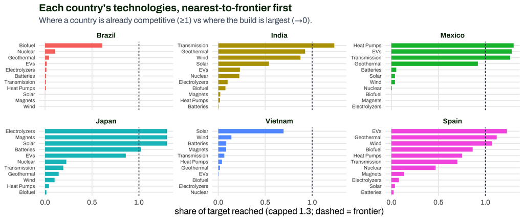

```r
ggplot(front, aes(x = reorder(interaction(country, tech), frontier), y = pmin(frontier,1.3), fill = country)) +
  geom_col(width=.7, show.legend = FALSE) + coord_flip() +
  facet_wrap(~country, scales = "free_y", ncol = 3) +
  geom_hline(yintercept = 1, linetype = "22", colour = "#334155") +
  scale_x_discrete(labels = function(x) sub("\\..*","", sub("^[^.]*\\.","",x))) +
  labs(x = NULL, y = "share of target reached (capped 1.3; dashed = frontier)",
       title = "Each country's technologies, nearest-to-frontier first",
       subtitle = "Where a country is already competitive (≥1) vs where the build is largest (→0).") +
  theme(strip.text = element_text(face="bold", colour=NZ_DARK), axis.text.y = element_text(size=7))
```

**Reading the board.** In the heatmap, rows are countries and columns technologies; each cell is that country’s overall share of the technology’s target — dark green means at or beyond the frontier, pale means a long way to go. The companion panel simply re-sorts the same numbers within each country, so a country’s technologies line up from “already competitive” (bars past the dashed line) to “largest build ahead” (bars near zero). Read together, they turn a country’s industrial-policy question into a short list: the bars nearest the frontier are where an existing base can be defended and extended; the ones near zero are green-field bets. The radars in the next two sections open up any one of these cells to show *which capabilities* drive the number.

# 3 Gap radars — relative view (share of the frontier reached)

This is the “how close, and where” view. In every panel the dashed pentagon is the target frontier (100% on all five clusters), and the green fill is the fraction the country has reached on each — so a full pentagon means “already at the winners’ level,” and a short spoke is a build priority. Because every technology is normalised to its own frontier, panels are directly comparable *across* technologies: a nearly full Solar and a nearly empty Wind tell you, at a glance, where a country’s base is strong and where it starts from scratch. The trade-off, addressed by the absolute view that follows, is that this normalisation hides *how large* each technology’s underlying need is.

```r
ang <- tibble(cluster = factor(CATS, CATS), a = pi/2 - 2*pi*(0:4)/5)

# close a per-tech polygon back to its first vertex so the pentagon draws shut
close_poly <- function(d, grp) bind_rows(d, d |> filter(cluster == CATS[1]) |> mutate(o = 6L)) |>
  arrange(across(all_of(grp)), o)

# shared pentagon grid (rings + spokes + axis labels) for a set of techs
grid_layers <- function(techs) {
  rings <- expand_grid(tech = factor(techs, TECHS), ring = c(.33,.66,1), cluster = factor(CATS,CATS)) |>
    left_join(ang, by="cluster") |> mutate(x = ring*cos(a), y = ring*sin(a), o = as.integer(cluster))
  list(ringsc = bind_rows(rings, rings |> filter(cluster==CATS[1]) |> mutate(o=6L)) |> arrange(tech, ring, o),
       spokes = expand_grid(tech = factor(techs, TECHS), cluster = factor(CATS,CATS)) |>
         left_join(ang, by="cluster") |> mutate(x = cos(a), y = sin(a)),
       labs   = expand_grid(tech = factor(techs, TECHS), cluster = factor(CATS,CATS)) |>
         left_join(ang, by="cluster") |> mutate(x = 1.28*cos(a), y = 1.28*sin(a),
                                                 lab = CATS_SHORT[as.character(cluster)]))
}
base_grid <- function(g)
  list(geom_path(data = g$ringsc, aes(x,y,group=interaction(tech,ring)), colour="grey88", linewidth=.3),
       geom_segment(data = g$spokes, aes(0,0,xend=x,yend=y), colour="grey88", linewidth=.3),
       geom_text(data = g$labs, aes(x,y,label=lab), family="Archivo", size=2.1, colour="#475569"))
radar_theme <- function(ttl)
  list(facet_wrap(~tech, ncol=4), coord_equal(clip="off"), xlim(-1.5,1.5), ylim(-1.4,1.4),
       labs(title = ttl), theme_void(base_family="Archivo"),
       theme(strip.text = element_text(face="bold", colour=NZ_DARK, size=10),
             plot.title = element_text(face="bold", colour=NZ_DARK, size=12.5), legend.position="none"))

# RELATIVE view — outer pentagon = frontier (100%); green fill = share of it reached
rel_radar <- function(cty) {
  d <- gap |> filter(country == cty) |> left_join(ang, by = "cluster") |>
    mutate(x = ach*cos(a), y = ach*sin(a), o = as.integer(cluster))
  poly <- close_poly(d, "tech")
  g <- grid_layers(levels(droplevels(d$tech))); frame <- g$ringsc |> filter(ring == 1)
  ggplot() + base_grid(g) +
    geom_polygon(data = frame, aes(x,y,group=tech), fill=NA, colour="#94a3b8", linewidth=.7, linetype="22") +
    geom_polygon(data = poly, aes(x,y,group=tech), fill=NZ_GREEN, colour=NZ_TEAL, alpha=.42, linewidth=.7) +
    radar_theme(paste0(cty, " — RELATIVE: share of the frontier reached (dashed pentagon = 100% target)"))
}

# ABSOLUTE view — the need in each tech's own colour vs what the country holds in green,
# both on a shared per-panel scale so the shapes (and any surplus) are directly comparable
abs_radar <- function(cty) {
  d <- gap |> filter(country == cty) |>
    transmute(tech, cluster, need = target_weight, hold = pmax(country_signed, 0)) |>
    pivot_longer(c(need, hold), names_to = "series", values_to = "val") |>
    group_by(tech) |> mutate(r = coalesce(val / max(val, na.rm=TRUE), 0)) |> ungroup() |>
    left_join(ang, by = "cluster") |>
    mutate(x = r*cos(a), y = r*sin(a), o = as.integer(cluster),
           fillc = ifelse(series == "need", TECH_COLORS[as.character(tech)], CGREEN))
  polyN <- close_poly(d |> filter(series == "need"), "tech")
  polyH <- close_poly(d |> filter(series == "hold"), "tech")
  g <- grid_layers(levels(droplevels(factor(d$tech, TECHS))))
  ggplot() + base_grid(g) +
    geom_polygon(data = polyN, aes(x,y,group=tech, fill=fillc, colour=fillc), alpha=.16, linewidth=.9) +
    geom_polygon(data = polyH, aes(x,y,group=tech), fill=CGREEN, colour="#15803d", alpha=.5, linewidth=.6) +
    scale_fill_identity() + scale_colour_identity() +
    radar_theme(paste0(cty, " — ABSOLUTE: the need (tech colour) vs what the country holds (green)"))
}
```

**Brazil**

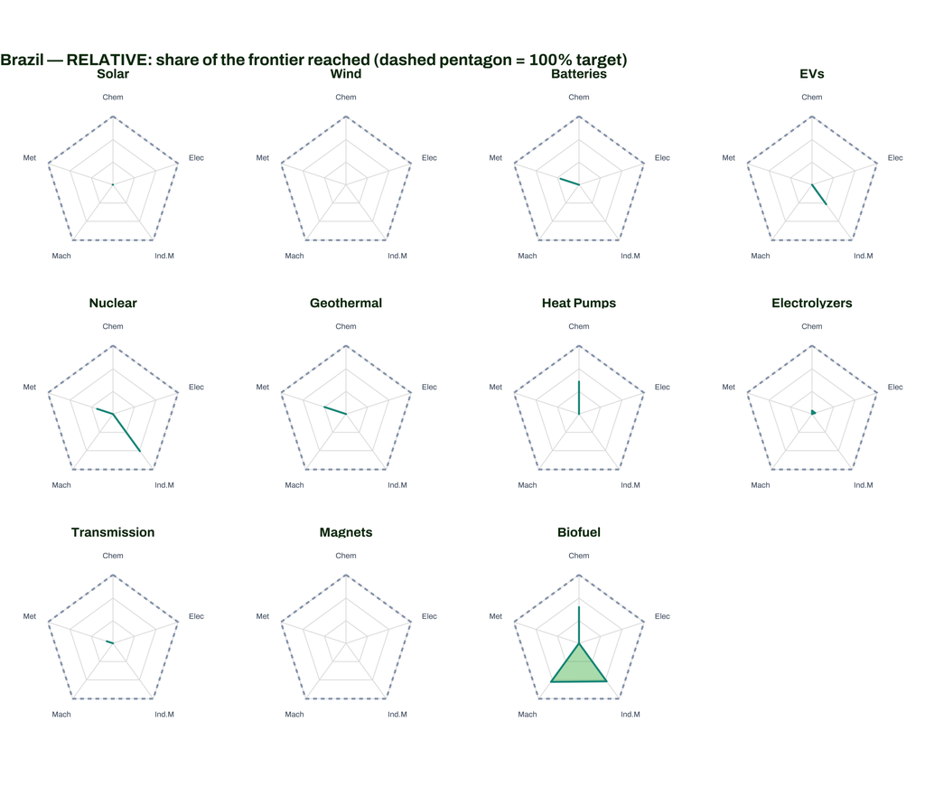

```r
rel_radar("Brazil")
```

**India**

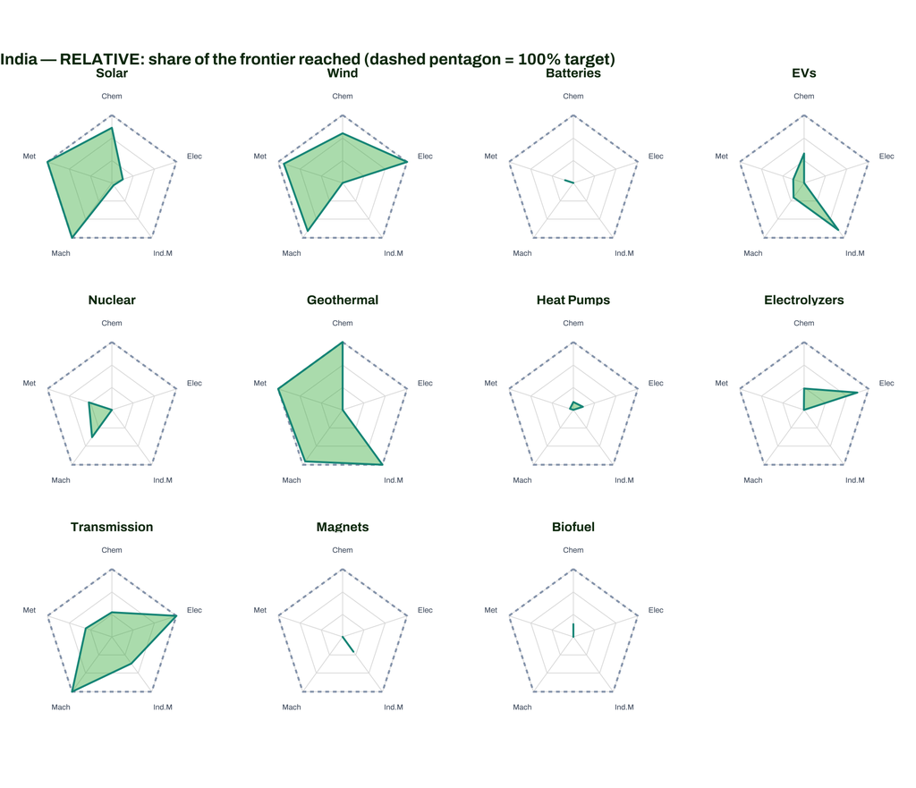

```r
rel_radar("India")
```

**Mexico**

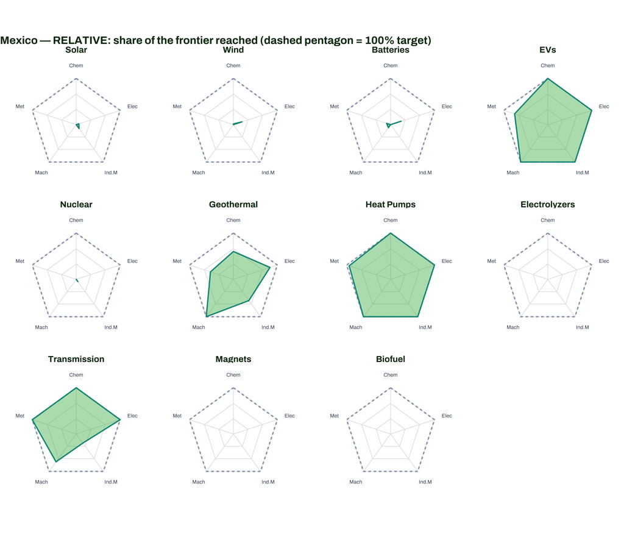

```r
rel_radar("Mexico")
```

**Japan**

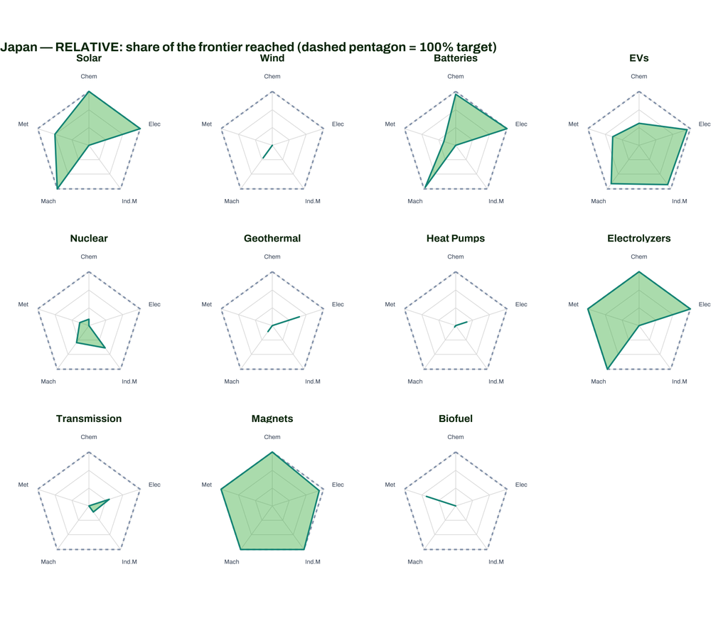

```r
rel_radar("Japan")
```

**Vietnam**

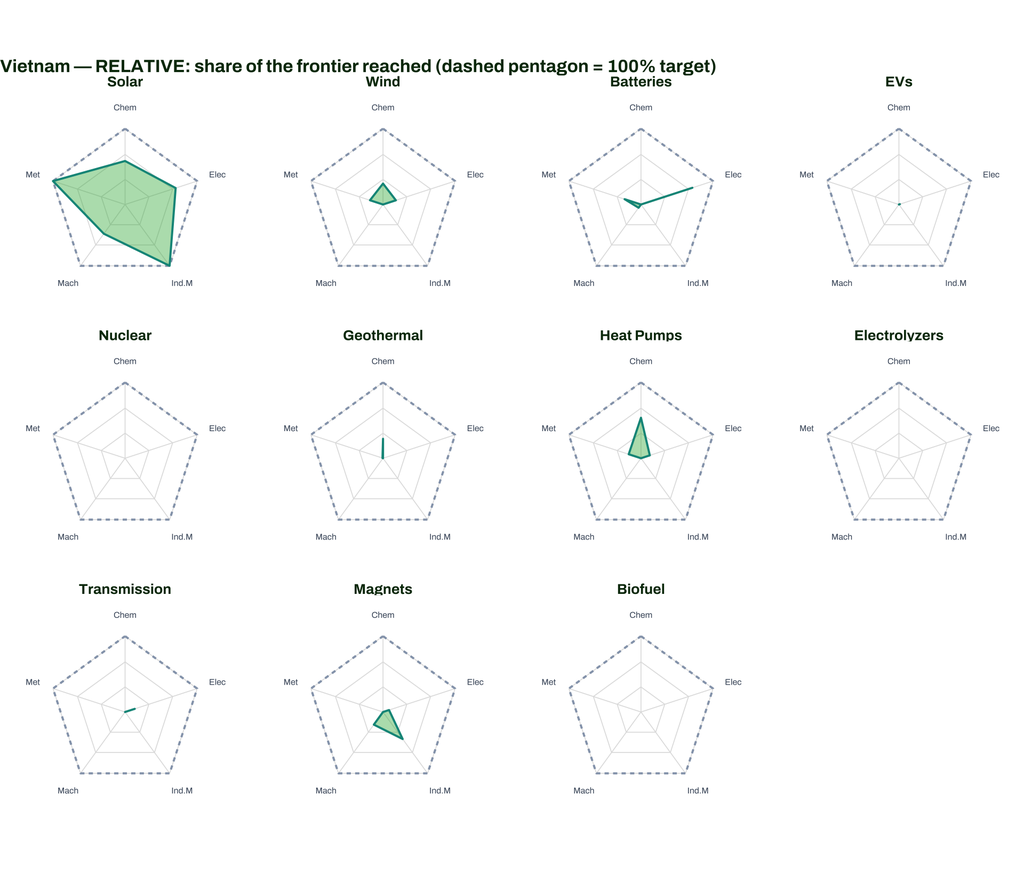

```r
rel_radar("Vietnam")
```

**Spain**

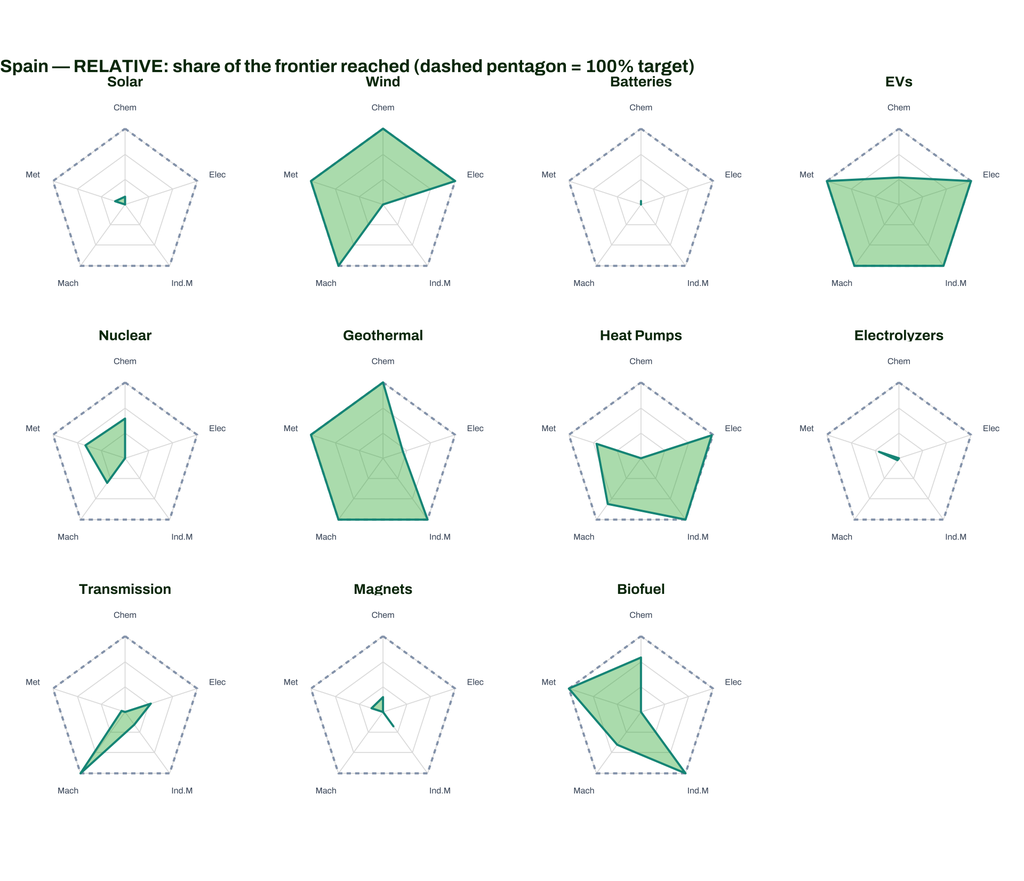

```r
rel_radar("Spain")
```

# 4 Gap radars — absolute view (the need vs what the country holds)

The relative view above deliberately erased scale so technologies could be compared; this view puts it back. In each panel the coloured pentagon is the technology’s **need profile** — the winners’ recipe, drawn in that technology’s own Atlas colour — and the green shape is **what the country actually holds** (its recent positive signed SHAP per cluster), both on a shared per-panel scale. Now the reading is literal: the coloured boundary is the target *shape*, and the green shows how much of it is filled. Where green falls short of the colour, that is the build; where green pokes beyond it, a surplus. This view earns its keep exactly where the relative one struggles — a technology a country has barely entered shows as a full coloured need with only a sliver of green inside, which is far more legible than a near-empty pentagon. Read the two views as a pair: the relative one ranks *how close*, the absolute one shows *the shape of what is missing*.

**Brazil**

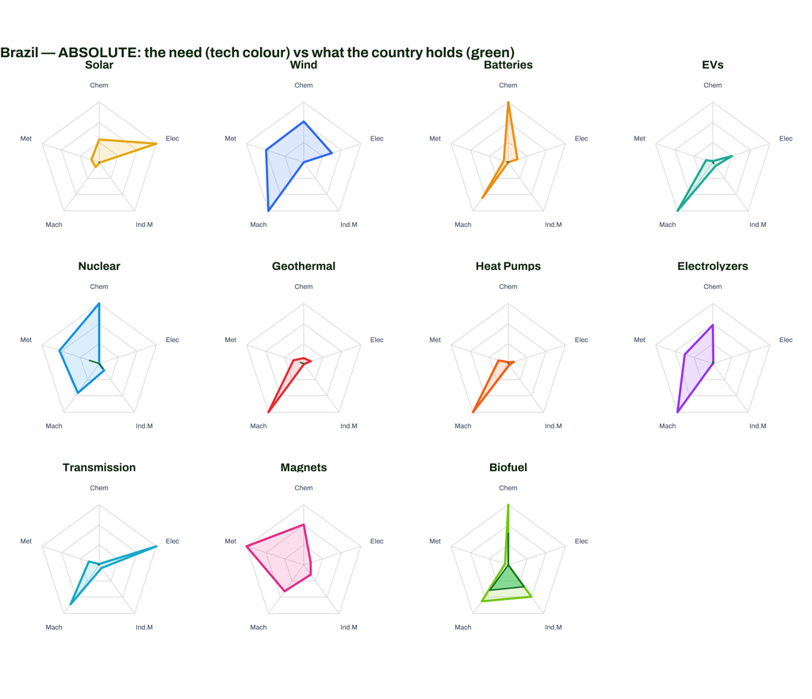

```r
abs_radar("Brazil")
```

**India**

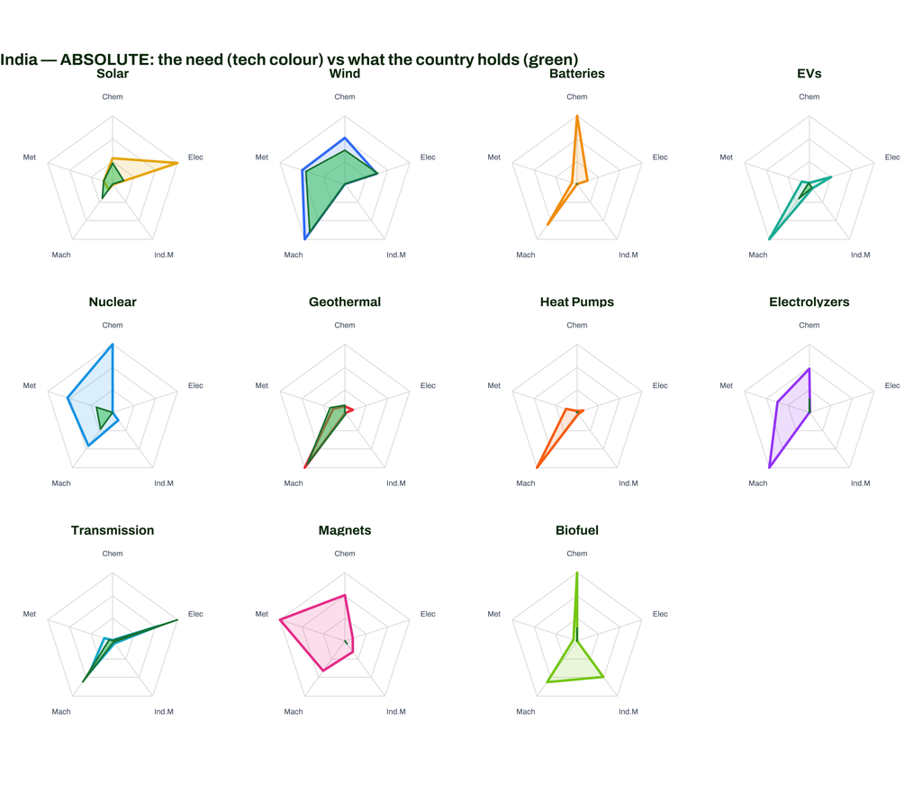

```r
abs_radar("India")
```

**Mexico**

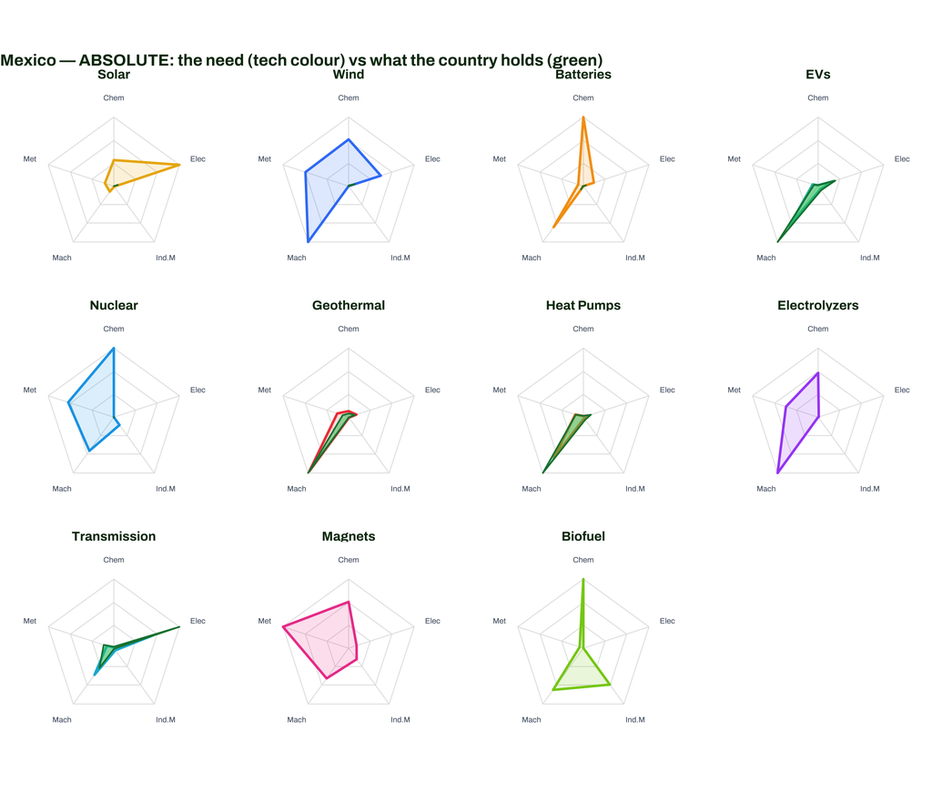

```r
abs_radar("Mexico")
```

**Japan**

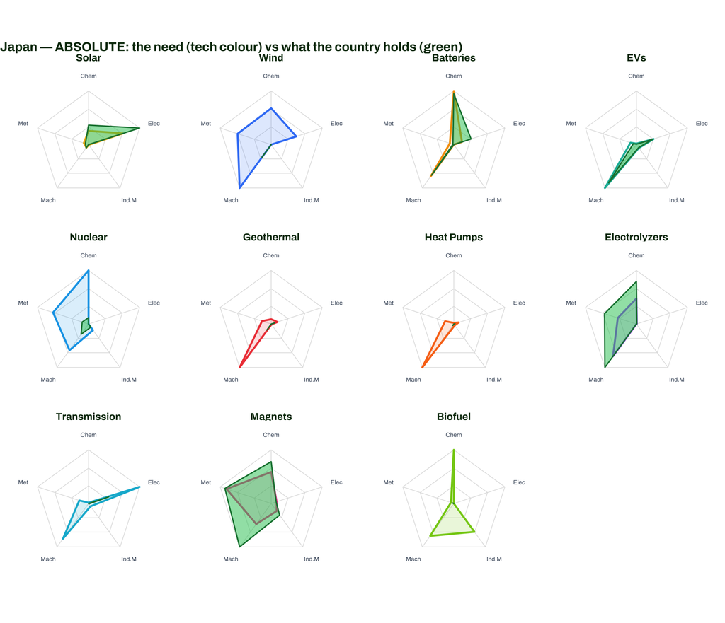

```r
abs_radar("Japan")
```

**Vietnam**

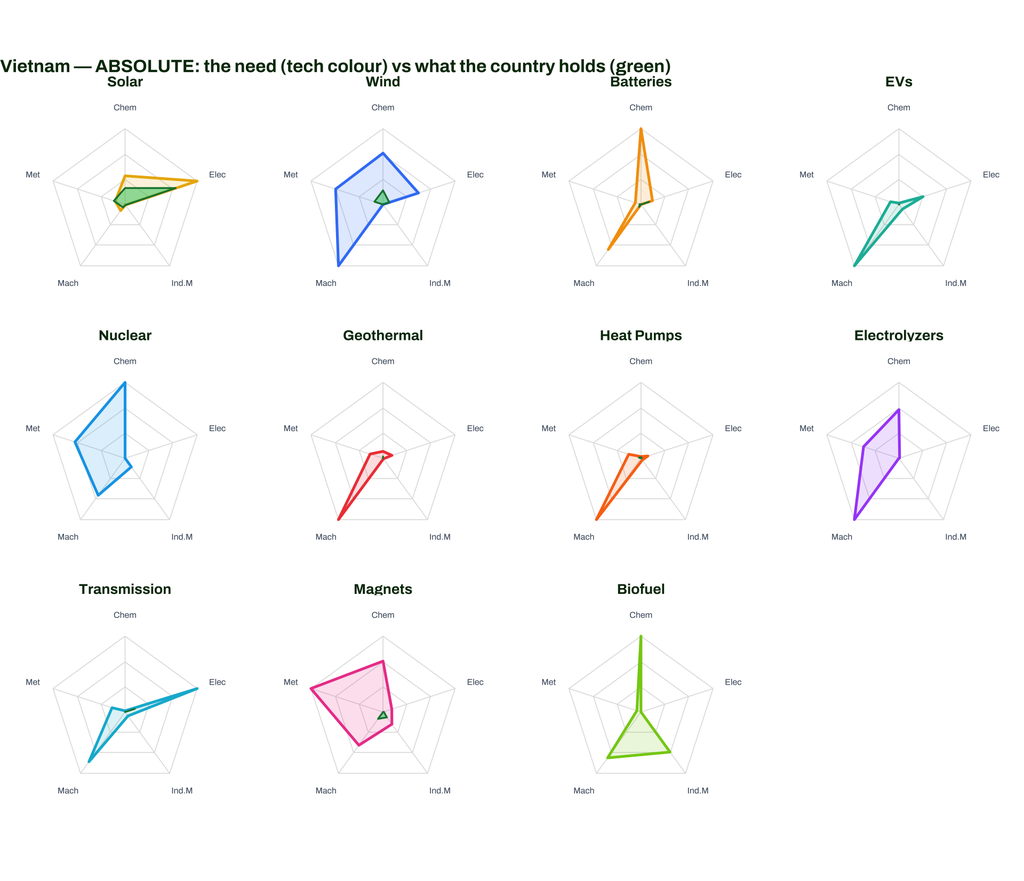

```r
abs_radar("Vietnam")
```

**Spain**

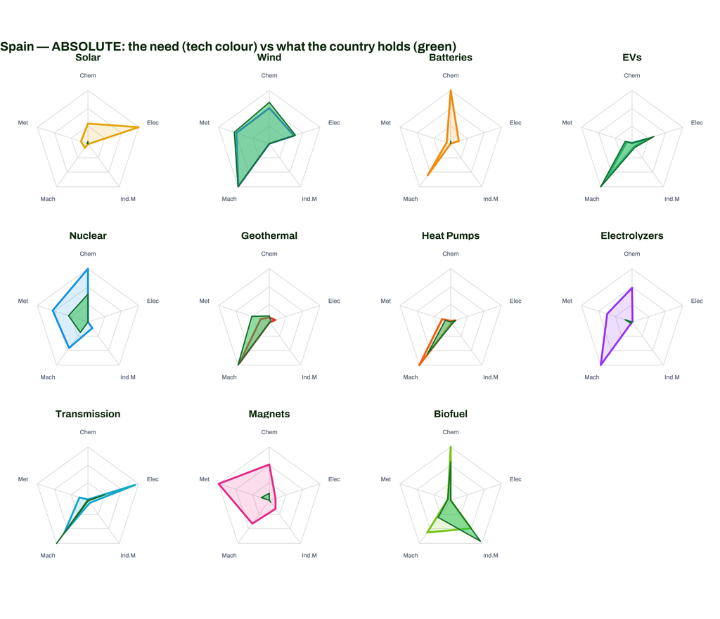

```r
abs_radar("Spain")
```

# 5 Build priorities — where the deficit is

Positive = deficit (build); negative = surplus (leverage / rotate). Sorted by the largest single-cluster deficit per country.

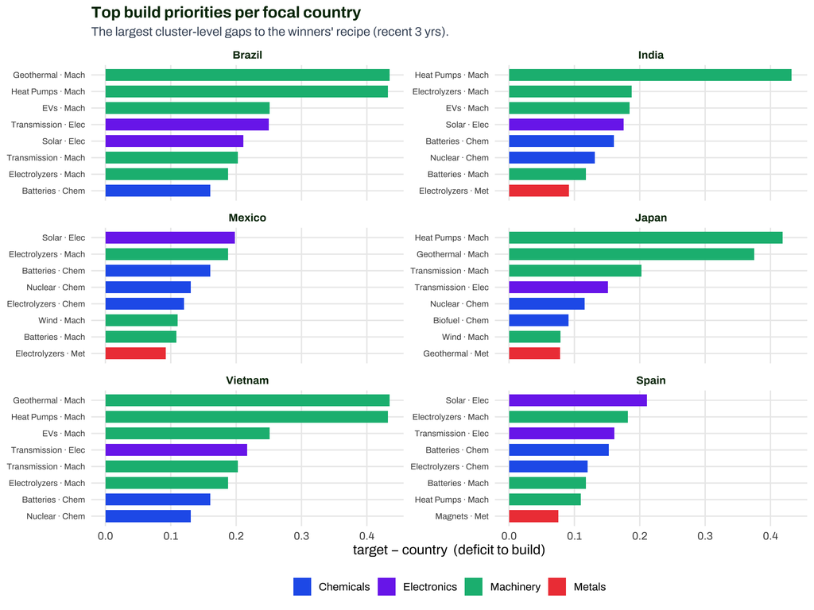

```r
pb <- gap |> mutate(country = factor(country, FOCAL)) |>
  group_by(country) |> slice_max(order_by = gap, n = 8, with_ties = FALSE) |> ungroup() |>
  mutate(lab = paste0(tech, " · ", CATS_SHORT[as.character(cluster)]))
ggplot(pb, aes(x = reorder_within(lab, gap, country), y = gap, fill = cluster)) +
  geom_col(width=.72) + coord_flip() +
  facet_wrap(~country, scales="free_y", ncol=2) +
  scale_fill_manual(values = CAT_COL, name = NULL) +
  scale_x_discrete(labels = function(x) sub("___.*","",x)) +
  labs(x=NULL, y="target − country  (deficit to build)",
       title="Top build priorities per focal country",
       subtitle="The largest cluster-level gaps to the winners' recipe (recent 3 yrs).") +
  theme(legend.position="bottom", strip.text=element_text(face="bold",colour=NZ_DARK),
        axis.text.y=element_text(size=7.5))
```

**Reading the bars.** The radars show a country’s whole position at a glance; this chart distils it into an ordered to-do list. Each bar is one technology × cluster, its length the raw deficit `target − country` — how much capability separates the country from the winners’ recipe in that specific cluster — and the eight longest per country are kept. A tall bar is where the single biggest, most concrete build lies (e.g. “Solar · Electronics” for a machinery-heavy economy); a bar that dips *below* zero is a surplus the country could lean on. This is the step from *diagnosis* to *agenda*: the frontier board says which technologies to prioritise, the radars say why, and these bars name the specific capability clusters a policy would target first.

# 6 Reading the gaps — three worked cases

The cluster tables below zoom all the way in on three country × technology pairs, so the numbers behind the shapes are visible. Read each as: the **Target** column is the winners’ recipe (what the technology needs), **Country (recent)** is what the country holds, and **Achieved** is their ratio — the same achievement fraction the radars draw, now as a figure you can quote.

```r
show_case <- function(cty, tch) gap |> filter(country==cty, tech==tch) |>
  transmute(Cluster=cluster, `Country (recent)`=round(country_signed,4), `Target`=round(target_weight,4),
            `Achieved`=sprintf("%.0f%%", pmin(achieved,9)*100),
            Read = case_when(achieved>=1.2~"surplus — leverage", achieved>=.8~"at frontier",
                             achieved>=.4~"partial — build", TRUE~"deep gap — priority")) |>
  arrange(desc(`Target`))
kable(show_case("India","Solar"), caption="India · Solar — machinery-heavy economy, but the Solar target is Electronics-led: Electronics is the deep gap, Machinery a surplus.")
```

India · Solar — machinery-heavy economy, but the Solar target is Electronics-led: Electronics is the deep gap, Machinery a surplus.

| Cluster | Country (recent) | Target | Achieved | Read |
| --- | --- | --- | --- | --- |
| Electronics | 0.0357 | 0.2108 | 17% | deep gap — priority |
| Chemicals | 0.0647 | 0.0796 | 81% | at frontier |
| Metals | 0.0290 | 0.0288 | 101% | at frontier |
| Machinery | 0.0544 | 0.0210 | 259% | surplus — leverage |
| Industrial Materials | 0.0001 | 0.0019 | 4% | deep gap — priority |

```r
kable(show_case("Brazil","Biofuel"), caption="Brazil · Biofuel.")
```

Brazil · Biofuel.

| Cluster | Country (recent) | Target | Achieved | Read |
| --- | --- | --- | --- | --- |
| Chemicals | 0.0480 | 0.0908 | 53% | partial — build |
| Machinery | 0.0473 | 0.0679 | 70% | partial — build |
| Industrial Materials | 0.0407 | 0.0593 | 69% | partial — build |
| Metals | 0.0000 | 0.0051 | 0% | deep gap — priority |
| Electronics | 0.0000 | 0.0000 | NA% | deep gap — priority |

```r
kable(show_case("Vietnam","Batteries"), caption="Vietnam · Batteries.")
```

Vietnam · Batteries.

| Cluster | Country (recent) | Target | Achieved | Read |
| --- | --- | --- | --- | --- |
| Chemicals | -0.0056 | 0.1602 | 0% | deep gap — priority |
| Machinery | 0.0062 | 0.1175 | 5% | deep gap — priority |
| Electronics | 0.0182 | 0.0256 | 71% | partial — build |
| Metals | 0.0028 | 0.0125 | 23% | deep gap — priority |
| Industrial Materials | 0.0000 | 0.0000 | NA% | deep gap — priority |

**How to use this.** For any focal country, the radar shows *how competitive its capability base already is per technology* (fullness) and *where the model says the missing pieces are* (short axes) — read against a target that is the same for everyone, so the comparison is apples-to-apples. The build-priority bars turn that into a ranked list; the frontier board shows which technologies are within reach vs distant. Unlike the shipped count-driven radar, this is **magnitude-preserving, signed, and country-specific** — the three things the audit flagged as missing, now supplied by the raw SHAP.

# 7 Reproducibility

`scripts/ml/target_profile_prep.py` writes `analysis/ml/shap_gap_by_country_cluster.csv` (per country × tech × cluster: country recent-3yr signed SHAP, target weight, achieved fraction, gap) from `analysis/ml/raw_signed/` and the winners’-recipe target. Country value uses the last 3 available years (option A). No model re-fit.